# 4.1.데이터 분할 기법

## 데이터 샘플링

- 데이터 분석을 진행할 때, 전체 데이터를 모두 활용하는 것은 수많은 시간과 비용이 들 수 있다.
- 본 장에서는 데이터 샘플링의 방법과 python을 활용한 표본 추출에 대해 학습한다.

### 통계

- 통계란 특정집단을 대상으로 수행한 조사나 실험을 통해 나온 결과에 대한 요약된 형태의 표현이다.
- 조사 또는 실험을 통해 데이터를 확보하며, 조사대상에 따라 총조사와 표본조사로 구분한다.

### 통계자료의 흭득 방법

**가. 총 조사/ 전수조사**

- 총 조사란 대상 집단 모두를 조사하는 방법이며, 특별한 경우를 제외하고는 사용되지 않는다.

**나. 표본조사**

- 모집단(population) : 조사하고자 하는 대상 집단 전체
- 원소(element) : 모집단을 구성하는 개체
- 표본(sample) : 조사하기 위해 추출한 모집단의 일부 원소
- 모수(parameter) : 표본 관측에 의해 구하고자 하는 모집단에 대한 정보
- 모집단의 정의, 표본의 크기, 조사방법, 조사기간, 표본추출방법을 명확하게 정의해야 한다.

### 표본 추출 방법

- 표본조사에서 중요한 점은 모집단을 대표할 수 있는 표본의 추출이며, 표본 추출 방법에 따라 분석 결과의 해석은 큰 차이가 발생한다.

**가. 단순 임의 추출법**

- 각 개체에 번호를 부여하여 랜덤하게 n개를 추출하는 방법으로 모든 개체는 선택될 확률이 동일하다.
- 복원, 비복원 추출로 나누어진다.

**나. 계통추출법**

- 랜덤하게 정렬된 표본에서 시간 혹은 공간적으로 일정한 간격을 두고 표본을 추출하는 방법이다.
- 단순랜덤추출법의 변형된 방식으로 번호를 부여한 샘플을 나열하여 K개씩 n개의 구간으로 나누고 첫 구간에서 하나를 임의로 선택한 후에 K개씩 띄어서 표본을 선택한다. 즉 임의의 위치에서 매 k번째 항목을 추출하는 방법이다.

**다. 집락추출법**

- 군집을 구분하고 특정 군집을 먼저 선택한 후 해당 군집에서만 표본을 추출하는 방법이다.

**라. 층화추출법**

- 모집단이 이질적인 몇 개의 계층으로 이루어져 있을 때 모든 계층으로부터 원소를 임의로 추출하여 각 계층을 고루 대표할 수 있도록 랜덤하게 표본을 추출하는 방법이다.

### Python을 이용한 표본 추출

#### 단순 임의 추출

- 일반적으로 데이터를 training data와 test data로 분할할 때 가장 많이 사용하는 표본추출 방법이다.

**함수사용법 : DataFrame.sample(frac=0.7, random_state=2000)**

- n : 추출할 표본 개수
- frac : 추출할 표본 크기 비율
- replace : boolean, True이면 복원추출, False이면 비복원 추출

**[예제1]** iris 데이터로 분석을 진행하기 위해 전체 데이터의 7:3 비율로 training data와 test data를 추출한 뒤 새로운 변수에 저장해보자 ( 데이터 추출 방법은 단순 임의 추출을 이용한다.)

```python
import pandas as pd
import numpy as np
```

```python
iris = pd.read_csv('../../data/iris.csv')
```

```python
iris
```

|  | sepal length | sepal width | petal length | petal width | target |
| --- | --- | --- | --- | --- | --- |
| 0 | 5.1 | 3.5 | 1.4 | 0.2 | Iris-setosa |
| 1 | 4.9 | 3.0 | 1.4 | 0.2 | Iris-setosa |
| 2 | 4.7 | 3.2 | 1.3 | 0.2 | Iris-setosa |
| 3 | 4.6 | 3.1 | 1.5 | 0.2 | Iris-setosa |
| 4 | 5.0 | 3.6 | 1.4 | 0.2 | Iris-setosa |
| ... | ... | ... | ... | ... | ... |
| 145 | 6.7 | 3.0 | 5.2 | 2.3 | Iris-virginica |
| 146 | 6.3 | 2.5 | 5.0 | 1.9 | Iris-virginica |
| 147 | 6.5 | 3.0 | 5.2 | 2.0 | Iris-virginica |
| 148 | 6.2 | 3.4 | 5.4 | 2.3 | Iris-virginica |
| 149 | 5.9 | 3.0 | 5.1 | 1.8 | Iris-virginica |

150 rows × 5 columns

```python
iris.info()
```

```
<class 'pandas.core.frame.DataFrame'>
RangeIndex: 150 entries, 0 to 149
Data columns (total 5 columns):
 #   Column        Non-Null Count  Dtype
---  ------        --------------  -----
 0   sepal length  150 non-null    float64
 1   sepal width   150 non-null    float64
 2   petal length  150 non-null    float64
 3   petal width   150 non-null    float64
 4   target        150 non-null    object
dtypes: float64(4), object(1)
memory usage: 6.0+ KB
```

```python
training = iris.sample(frac=0.7, random_state=2000)
```

```python
training.info()
```

[output not shown]

```python
iris['target'].value_counts()
```

```
Iris-versicolor    50
Iris-virginica     50
Iris-setosa        50
Name: target, dtype: int64
```

```python
training['target'].value_counts()
```

```
Iris-virginica     38
Iris-versicolor    35
Iris-setosa        32
Name: target, dtype: int64
```

```python
training = iris.sample(frac=0.7, random_state=52)
test = iris.sample(frac=0.3, random_state=48)
```

```python
training.index
```

```
Int64Index([ 19,  84,  27,  94, 128, 129, 103,  83,   3,  34,
            ...
            101, 138,  60,  40,  92,  78,  26, 134,  21,  24],
           dtype='int64', length=105)
```

```python
len(iris)
```

```
150
```

```python
len(training)
```

```
105
```

```python
len(test)
```

```
45
```

```python
training[training.index.isin(test.index)]
```

|  | sepal length | sepal width | petal length | petal width | target |
| --- | --- | --- | --- | --- | --- |
| 19 | 5.1 | 3.8 | 1.5 | 0.3 | Iris-setosa |
| 84 | 5.4 | 3.0 | 4.5 | 1.5 | Iris-versicolor |
| 129 | 7.2 | 3.0 | 5.8 | 1.6 | Iris-virginica |
| 103 | 6.3 | 2.9 | 5.6 | 1.8 | Iris-virginica |
| 136 | 6.3 | 3.4 | 5.6 | 2.4 | Iris-virginica |
| 96 | 5.7 | 2.9 | 4.2 | 1.3 | Iris-versicolor |
| 127 | 6.1 | 3.0 | 4.9 | 1.8 | Iris-virginica |
| 70 | 5.9 | 3.2 | 4.8 | 1.8 | Iris-versicolor |
| 38 | 4.4 | 3.0 | 1.3 | 0.2 | Iris-setosa |
| 110 | 6.5 | 3.2 | 5.1 | 2.0 | Iris-virginica |
| 77 | 6.7 | 3.0 | 5.0 | 1.7 | Iris-versicolor |
| 126 | 6.2 | 2.8 | 4.8 | 1.8 | Iris-virginica |
| 89 | 5.5 | 2.5 | 4.0 | 1.3 | Iris-versicolor |
| 11 | 4.8 | 3.4 | 1.6 | 0.2 | Iris-setosa |
| 88 | 5.6 | 3.0 | 4.1 | 1.3 | Iris-versicolor |
| 116 | 6.5 | 3.0 | 5.5 | 1.8 | Iris-virginica |
| 73 | 6.1 | 2.8 | 4.7 | 1.2 | Iris-versicolor |
| 87 | 6.3 | 2.3 | 4.4 | 1.3 | Iris-versicolor |
| 120 | 6.9 | 3.2 | 5.7 | 2.3 | Iris-virginica |
| 39 | 5.1 | 3.4 | 1.5 | 0.2 | Iris-setosa |
| 111 | 6.4 | 2.7 | 5.3 | 1.9 | Iris-virginica |
| 149 | 5.9 | 3.0 | 5.1 | 1.8 | Iris-virginica |
| 99 | 5.7 | 2.8 | 4.1 | 1.3 | Iris-versicolor |
| 62 | 6.0 | 2.2 | 4.0 | 1.0 | Iris-versicolor |
| 56 | 6.3 | 3.3 | 4.7 | 1.6 | Iris-versicolor |
| 31 | 5.4 | 3.4 | 1.5 | 0.4 | Iris-setosa |
| 132 | 6.4 | 2.8 | 5.6 | 2.2 | Iris-virginica |
| 137 | 6.4 | 3.1 | 5.5 | 1.8 | Iris-virginica |
| 33 | 5.5 | 4.2 | 1.4 | 0.2 | Iris-setosa |
| 138 | 6.0 | 3.0 | 4.8 | 1.8 | Iris-virginica |
| 78 | 6.0 | 2.9 | 4.5 | 1.5 | Iris-versicolor |
| 134 | 6.1 | 2.6 | 5.6 | 1.4 | Iris-virginica |

#### 층화 임의 추출

- X: 데이터 테이블
- test_size : 테스트 사이즈 비율
- shuffle : True이면 무작위 추출, False이면 체계적 추출
- random_state : 난수 // 임의의 번호 지정하면 되며 같은 번호라면 같은 값이 나온다.

```python
iris.info()
```

```
<class 'pandas.core.frame.DataFrame'>
RangeIndex: 150 entries, 0 to 149
Data columns (total 5 columns):
 #   Column        Non-Null Count  Dtype
---  ------        --------------  -----
 0   sepal length  150 non-null    float64
 1   sepal width   150 non-null    float64
 2   petal length  150 non-null    float64
 3   petal width   150 non-null    float64
 4   target        150 non-null    object
dtypes: float64(4), object(1)
memory usage: 6.0+ KB
```

```python
iris["target"].value_counts()
```

```
Iris-versicolor    50
Iris-virginica     50
Iris-setosa        50
Name: target, dtype: int64
```

```python
from sklearn.model_selection import train_test_split

X_train, X_test = train_test_split(iris, test_size=0.3, shuffle=True, stratify=iris["target"], random_state=1004)
```

```python
X_train
```

|  | sepal length | sepal width | petal length | petal width | target |
| --- | --- | --- | --- | --- | --- |
| 109 | 7.2 | 3.6 | 6.1 | 2.5 | Iris-virginica |
| 6 | 4.6 | 3.4 | 1.4 | 0.3 | Iris-setosa |
| 73 | 6.1 | 2.8 | 4.7 | 1.2 | Iris-versicolor |
| 78 | 6.0 | 2.9 | 4.5 | 1.5 | Iris-versicolor |
| 45 | 4.8 | 3.0 | 1.4 | 0.3 | Iris-setosa |
| ... | ... | ... | ... | ... | ... |
| 14 | 5.8 | 4.0 | 1.2 | 0.2 | Iris-setosa |
| 69 | 5.6 | 2.5 | 3.9 | 1.1 | Iris-versicolor |
| 31 | 5.4 | 3.4 | 1.5 | 0.4 | Iris-setosa |
| 11 | 4.8 | 3.4 | 1.6 | 0.2 | Iris-setosa |
| 2 | 4.7 | 3.2 | 1.3 | 0.2 | Iris-setosa |

105 rows × 5 columns

```python
X_test["target"].value_counts()
```

[output not shown]

```python
X_test.index.sort_values()
```

```
Int64Index([  3,   5,   8,  17,  25,  27,  28,  32,  35,  38,  39,  40,  46,
             52,  54,  56,  59,  61,  63,  65,  67,  74,  76,  84,  87,  88,
             93,  94, 102, 107, 108, 112, 114, 117, 123, 124, 129, 130, 131,
            132, 133, 136, 143, 146, 148],
           dtype='int64')
```

```python
X_train.index.sort_values()
```

```
Int64Index([  0,   1,   2,   4,   6,   7,   9,  10,  11,  12,
            ...
            137, 138, 139, 140, 141, 142, 144, 145, 147, 149],
           dtype='int64', length=105)
```

```python
X_train["target"].value_counts()
```

[output not shown]

## 언더 샘플링 & 오버 샘플링

### 언더샘플링

- 다수 클래스 의 샘플은 소수 클래스와 비교할 때 분포 비율과 일치하도록 무작위로 제거함.
- 2개의 클래스의 비율을 맞추기 위해 귀중한 정보를 잃어버리고 편향될 수 있기 때문에 일반적으로 선호되지 않음

### 오버 샘플링

- 소수 클래스의 샘플을 증가시켜 마이너 클래스와 메이저 클래스의 샘플 크기를 동일하게 만드는 기법
- 랜덤 오버샘플링(소수 샘플 복제)은 동일한 정보를 복사하여 오버피팅을 유발할 수 있음

### SMOTE(Synthetic Minority Over-sampling Technique)

- 소수 클래스의 기존 샘플을 사용하여 새로운 합성 관찰을 생성 하는 오버 샘플링 기법 소수 클래스에 대한 선형 보간법으로 가상 훈련 기록을 생성.
- 합성 훈련 기록은 소수 클래스의 각 예에 대해 k-최근접 이웃 중 하나 이상을 무작위로 선택하여 생성.
- 오버샘플링 과정을 거친 후 데이터를 재구성하고 처리된 데이터에 대해 여러 분류 모델을 적용할 수 있음
- 데이터의 특성에 따라 다르겠지만, 빅데이터 분석을 위해서는 많은 데이터 확보가 효과적이므로 오버샘플링 기법을 적용하는 것이 좋음.
- 기존의 데이터가 적은 새로운 사례의 데이터에서 사용하기 어려움.

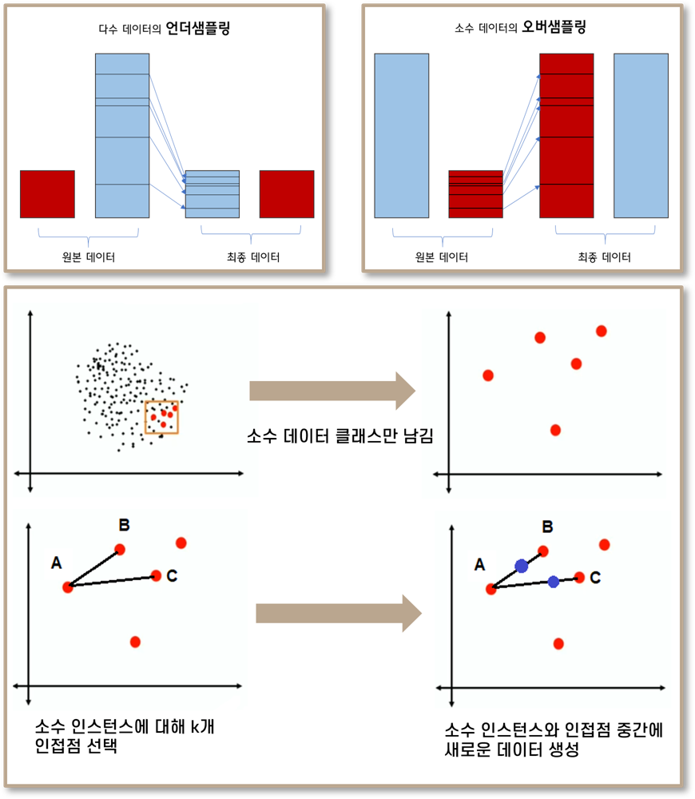

```python
from PIL import Image
image1 = Image.open("./오버샘플링_언더샘플링 소개.png")
image1.resize((870,1000))
```

```python
df_t = pd.read_csv('../../data/titanic.csv')
```

```python
df_t['survived'].value_counts()
```

```
0    549
1    342
Name: survived, dtype: int64
```

```python
from imblearn.over_sampling import SMOTE
```

```python
!conda install -c conda-forge imbalanced-learn -y
```

[output not shown]

```python
df_t = df_t.dropna()
```

```python
df_t
```

|  | survived | pclass | sex | age | sibsp | parch | fare | embarked | class | adult_male | embark_town |
| --- | --- | --- | --- | --- | --- | --- | --- | --- | --- | --- | --- |
| 0 | 0 | 3 | male | 22.0 | 1 | 0 | 7.2500 | S | Third | True | Southampton |
| 1 | 1 | 1 | female | 38.0 | 1 | 0 | 71.2833 | C | First | False | Cherbourg |
| 2 | 1 | 3 | female | 26.0 | 0 | 0 | 7.9250 | S | Third | False | Southampton |
| 3 | 1 | 1 | female | 35.0 | 1 | 0 | 53.1000 | S | First | False | Southampton |
| 4 | 0 | 3 | male | 35.0 | 0 | 0 | 8.0500 | S | Third | True | Southampton |
| ... | ... | ... | ... | ... | ... | ... | ... | ... | ... | ... | ... |
| 885 | 0 | 3 | female | 39.0 | 0 | 5 | 29.1250 | Q | Third | False | Queenstown |
| 886 | 0 | 2 | male | 27.0 | 0 | 0 | 13.0000 | S | Second | True | Southampton |
| 887 | 1 | 1 | female | 19.0 | 0 | 0 | 30.0000 | S | First | False | Southampton |
| 889 | 1 | 1 | male | 26.0 | 0 | 0 | 30.0000 | C | First | True | Cherbourg |
| 890 | 0 | 3 | male | 32.0 | 0 | 0 | 7.7500 | Q | Third | True | Queenstown |

712 rows × 11 columns

```python
X = df_t[['age','sibsp','parch','fare']]
y = df_t['survived']
```

```python
from sklearn.model_selection import train_test_split

X_train, X_test, y_train, y_test = train_test_split(X, y, test_size=0.3, shuffle=True, stratify=y, random_state=1004)
```

```python
from sklearn.preprocessing import MinMaxScaler

scaler = MinMaxScaler(feature_range=(0, 1))

X_train = scaler.fit_transform(X_train)
```

```python
X_train.shape
```

```
(498, 4)
```

```python
y_train.value_counts()
```

```
0    297
1    201
Name: survived, dtype: int64
```

```python
# 모델설정
sm = SMOTE( k_neighbors=5)

# train데이터를 넣어 복제함
X_resampled, y_resampled = sm.fit_resample(X_train,y_train)

print('After OverSampling, the shape of train_X: {}'.format(X_resampled.shape))
print('After OverSampling, the shape of train_y: {} \n'.format(y_resampled.shape))

print("After OverSampling, counts of label '1': {}".format(sum(y_resampled==1)))
print("After OverSampling, counts of label '0': {}".format(sum(y_resampled==0)))
```

```
After OverSampling, the shape of train_X: (594, 4)
After OverSampling, the shape of train_y: (594,)

After OverSampling, counts of label '1': 297
After OverSampling, counts of label '0': 297
```